# Setting the map projection in ggplot

When you’re mapping a large area (like a continent or a large country) where the geometry is stored as geographic coordinates, you’ll essentially end up with a Mercator projection that distorts areas on the map.

This is less of a big deal for smaller areas like cities, and I guess it’s not a big deal if you and your audience doesn’t hate the Mercator projection (and I do hate it).

# Required packages

These example uses the following packages:

```r
library(tidyverse)
library(sf)
```

# Loading some sample data

I’ll demonstrate with map of the world and provincial boundaries in Canada. Both have geometry stored in WGS 84 coordinates.

Here is the world:

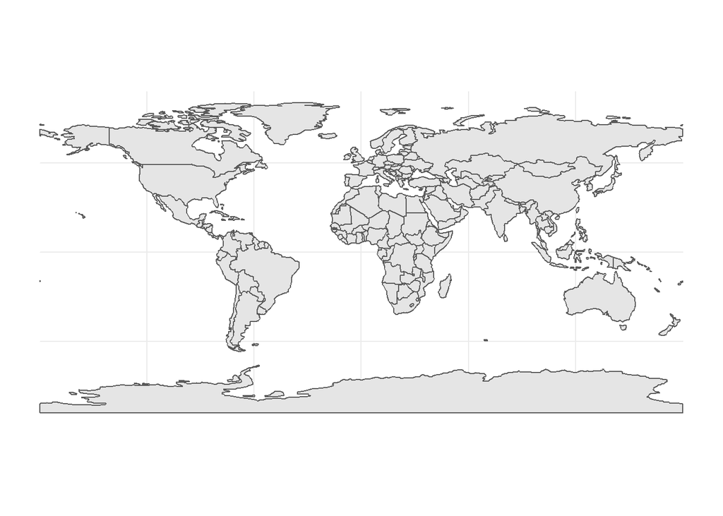

```r
wgs84_world <- ggplot(world) +
  geom_sf() +
  theme_minimal()

wgs84_world
```

And here are the Canadian provinces:

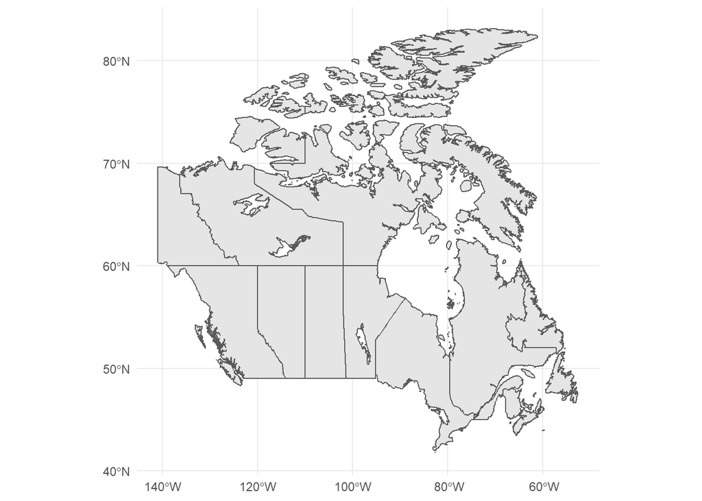

```r
wgs84_provinces <- ggplot(provinces) +
  geom_sf() +
  theme_minimal()

wgs84_provinces
```

The fidelity of these maps to actual areas and distances gets worse the further from the equator (north or south) you go. This may or may not be a problem for you, but if you’re using a Mercator projection, it should be because you’ve decided that it’s the best choice, not because you don’t know how to change it.

# Projections for world maps

The PROJ website has [a list of projections](https://proj.org/operations/projections/index.html) you can browse through, many of which could be suitable for a map of the world.

On the page for a projection, find the proj-string and use it to set the CRS for your map with the `coord_sf` function.

Examples include [azimuthal equidistant](https://proj.org/operations/projections/aeqd.html):

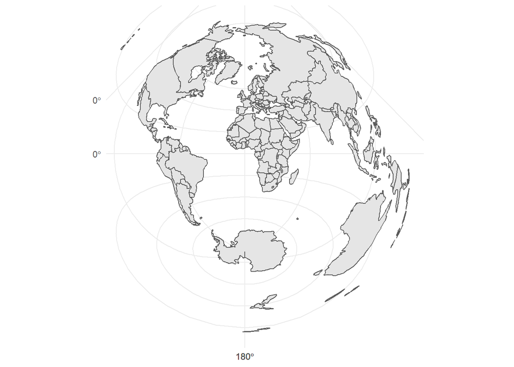

```r
wgs84_world +
  coord_sf(crs = "+proj=aeqd")
```

Or [equal earth](https://proj.org/operations/projections/eqearth.html):

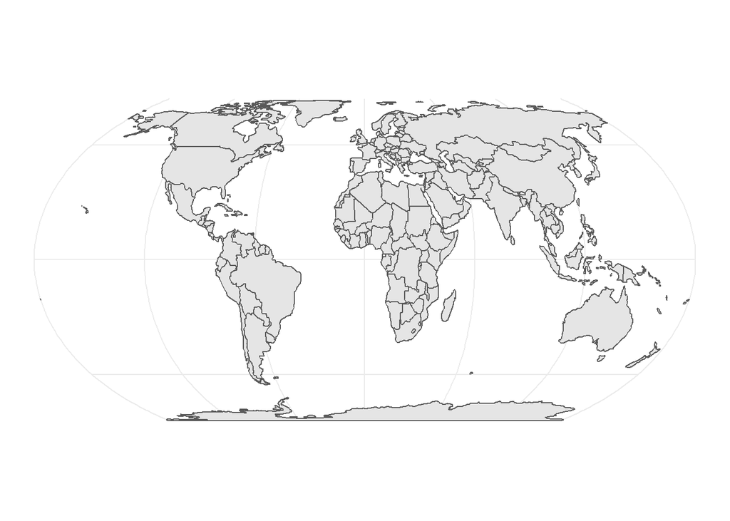

```r
wgs84_world +
  coord_sf(crs = "+proj=eqearth")
```

# PROJ strings

The examples above set the CRS with string starting with `+proj=`. This is proj4 notation, and it’s a common way to refer to a projection.

proj4 notation lets you set several additional parameters. The most important ones will often be to center your projection on a point near the middle of your map. If you don’t set parameters to center your projection, your projection will be centered on a point near the western part of Africa (zero degrees latitude and zero degrees longitude). This will look wacky if you’re mapping an area that’s far away from that point. For example, here is the azimuthal equidistant projection applied to Canada.

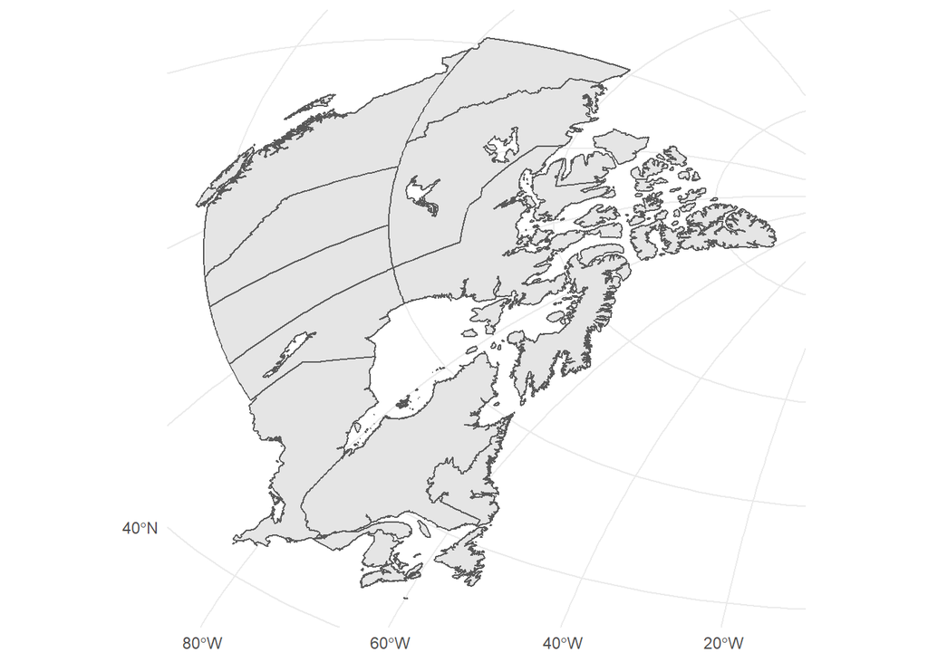

```r
wgs84_provinces +
  coord_sf(crs = "+proj=aeqd")
```

If you go back to the page for that projection (https://proj.org/operations/projections/aeqd.html), scroll down to “Options” and you’ll see that you can set parameters for `lat_0` and `lon_0`. You can use these to recenter the projection at 60 degrees north, 106 degrees west (about the middle of the northern border of Saskatchewan).

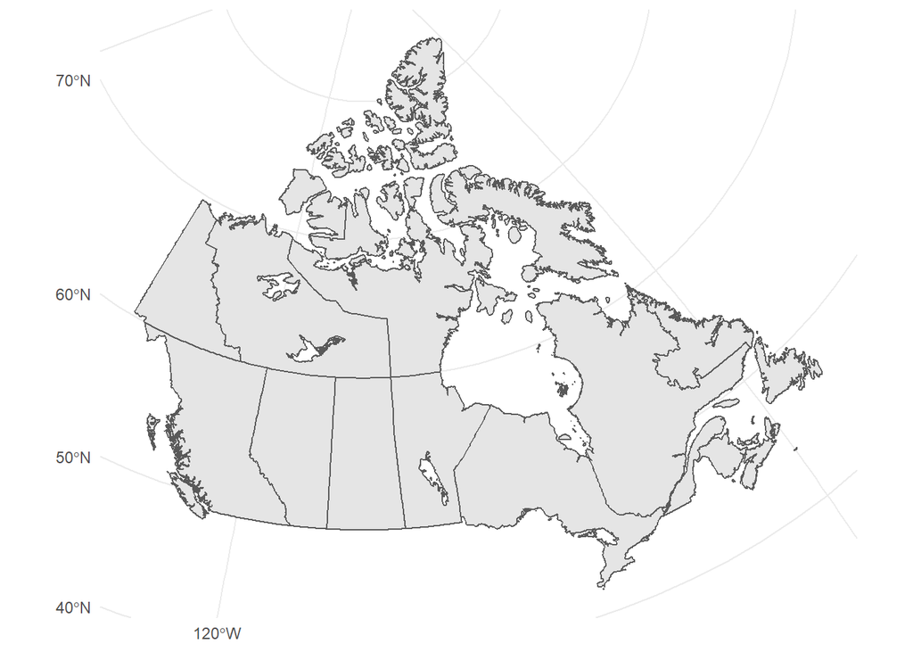

```r
wgs84_provinces +
  coord_sf(crs = "+proj=aeqd +lat_0=60 +lon_0=-106")
```

Some projections that were created specifically for world maps have parameters to center the map by longitude, but not by latitude. The Equal Earth projection is one of these.

Here is Canada in the Equal Earth projection centered on the prime meridian:

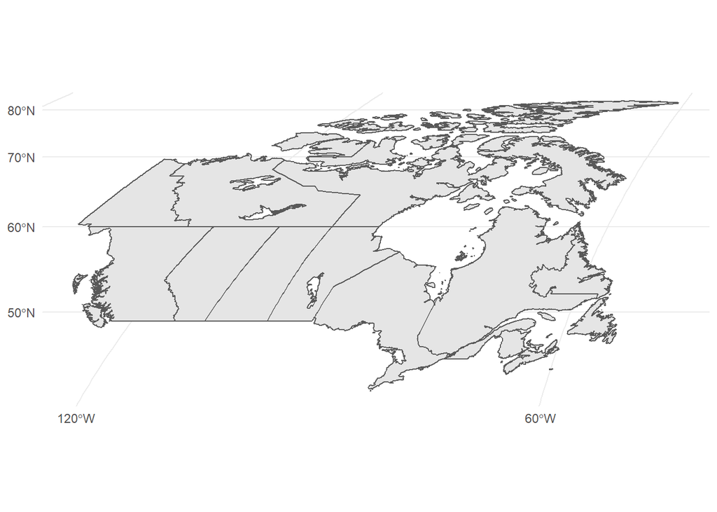

```r
wgs84_provinces +
  coord_sf(crs = "+proj=eqearth")
```

And here it is centered at 106 degrees west:

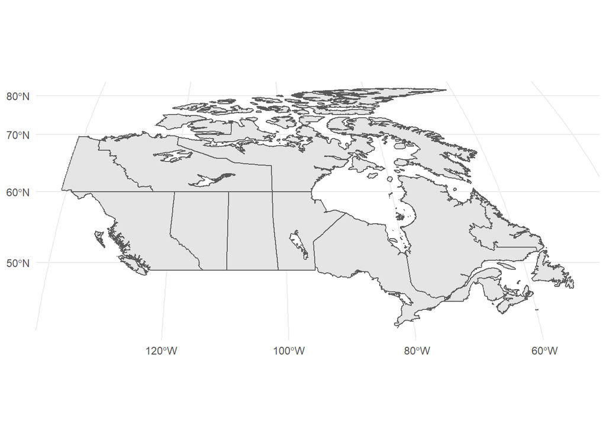

```r
wgs84_provinces +
  coord_sf(crs = "+proj=eqearth +lon_0=-106")
```